# Time series analysis using Atlanta's temp data over 20 years

Using the 20 years of daily high temperature data for Atlanta (July through October, (file `temps.txt`))

### Reading the data and creating a time series object

```r
# Read the data
temps <- read.table("temps.txt", sep="\t", stringsAsFactors = FALSE, header=T)
head(temps, 3)
```

| DAY | X1996 | X1997 | X1998 | X1999 | X2000 | X2001 | X2002 | X2003 | X2004 | ... | X2006 | X2007 | X2008 | X2009 | X2010 | X2011 | X2012 | X2013 | X2014 | X2015 |
| --- | --- | --- | --- | --- | --- | --- | --- | --- | --- | --- | --- | --- | --- | --- | --- | --- | --- | --- | --- | --- |
| 1-Jul | 98 | 86 | 91 | 84 | 89 | 84 | 90 | 73 | 82 | ... | 93 | 95 | 85 | 95 | 87 | 92 | 105 | 82 | 90 | 85 |
| 2-Jul | 97 | 90 | 88 | 82 | 91 | 87 | 90 | 81 | 81 | ... | 93 | 85 | 87 | 90 | 84 | 94 | 93 | 85 | 93 | 87 |
| 3-Jul | 97 | 93 | 91 | 87 | 93 | 87 | 87 | 87 | 86 | ... | 93 | 82 | 91 | 89 | 83 | 95 | 99 | 76 | 87 | 79 |

We first read our data into a tibble, then select all but the `DAY` column. We then convert our dataset into a vector of temperatures by concatenating all of the columns. We will then apply `ts()` to our vector. Since each year in our data has 123 days, we will set the `frequency` to `123` and the start parameter to `1996`

```r
suppressWarnings(suppressMessages(install.packages("dplyr")))
suppressWarnings(suppressMessages(library(dplyr)))

# Create a time series object of the temps data
temps_ts <- as_tibble(temps) %>%
    select(., -DAY) %>% unlist() %>% as.vector() %>% ts(start = c(1996, 1), frequency = 123)
```

### Plotting Time Series

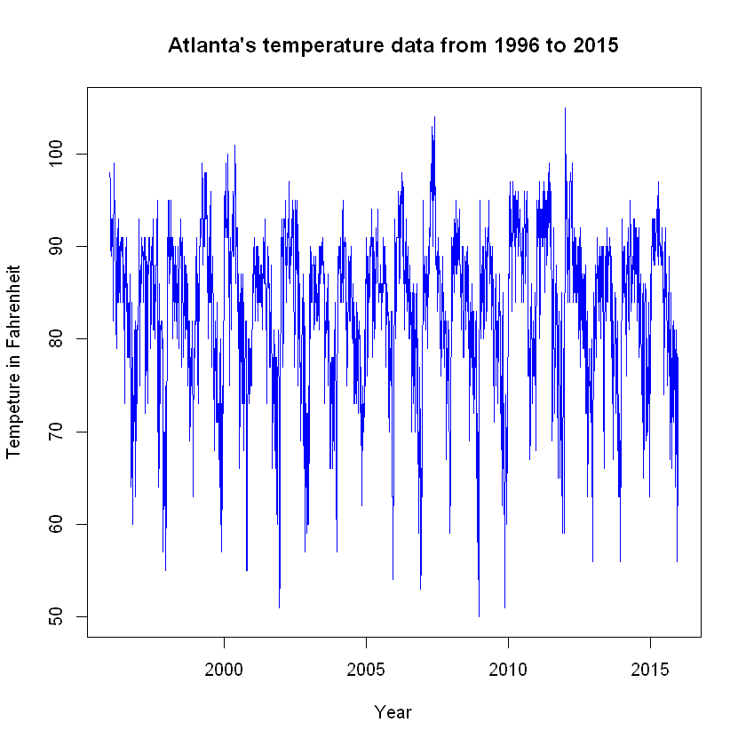

```r
# plot the temps time series
plot.ts(temps_ts, col = "blue",plot.type = c("multiple", "single"),
     main = "Atlanta's temperature data from 1996 to 2015",
     ylab = "Tempeture in Fahrenheit",
     xlab = "Year")
```

### Decomposing Time Series

`decompose()` let us estimate the trend, seasonal and random components of our temperature data

```r
# Decompose the time series
myts_decomposed <- decompose(temps_ts)
# myts_decomposed
```

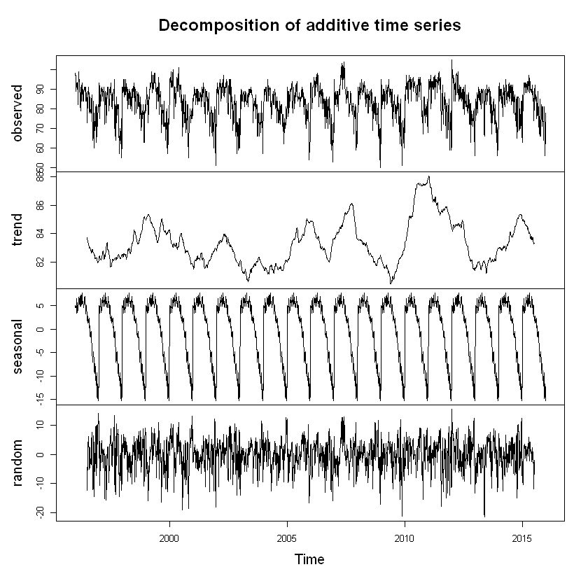

```r
# Plot the decomposed time series
plot(myts_decomposed)
```

- The plot above shows the original time series (top), the estimated trend component (second from top), the estimated seasonal component (third from top), and the estimated irregular(randomness or noise) component (bottom). We see that the estimated trend component shows an increase around 2011 then a gradual decrease around 2013 - 2014 followed by another increase around 2015
- By looking at the seasonal component of our decomposed time series, we see that the seasonality across 20 years are identical. This can be misleading because of how seasonality is being calculated in the `decompose()` function. The `decompose()` function computes seasonality by averaging, for each time unit, over all periods.
- We can adjust our original time series by removing the random/noise component from it and then apply decompose() on the adjusted time series

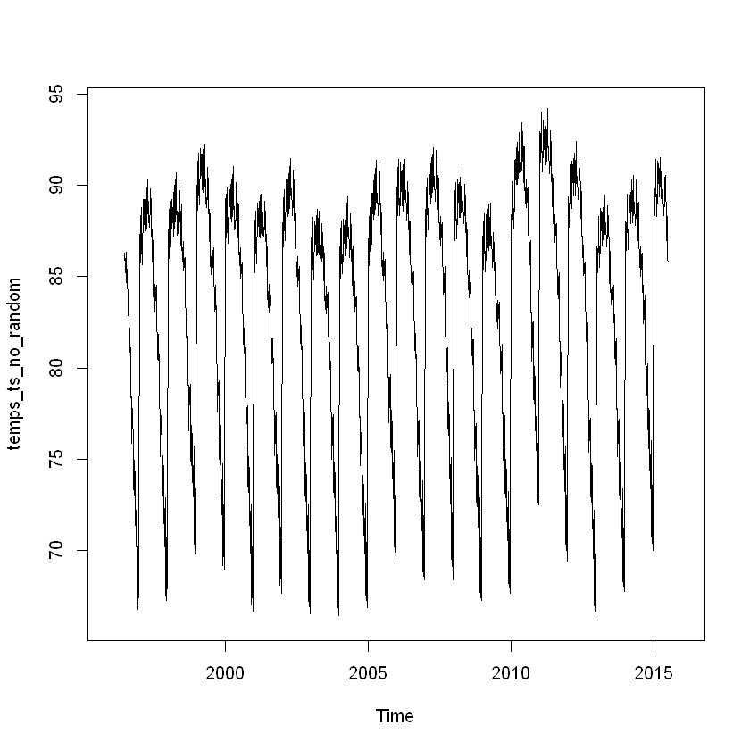

```r
# Remove the random component from our series
temps_ts_no_random <- temps_ts - myts_decomposed$random
plot.ts(temps_ts_no_random)
```

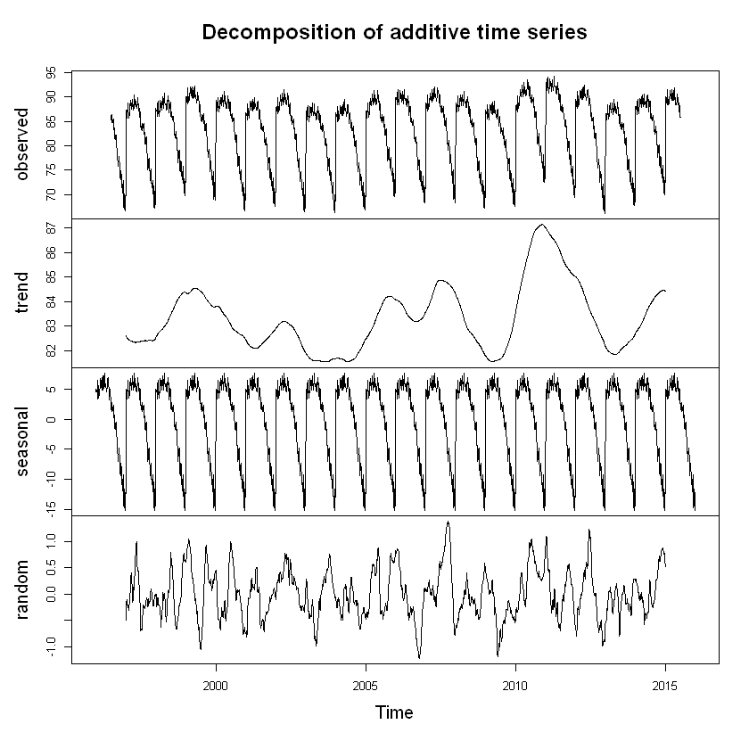

```r
# decompose the time series without the random component
temps_ts_no_random_decomp <- decompose(temps_ts_no_random)
plot(temps_ts_no_random_decomp)
```

Another way of clearky exposing seasonality is by de-trending our time series. This will results into a new series

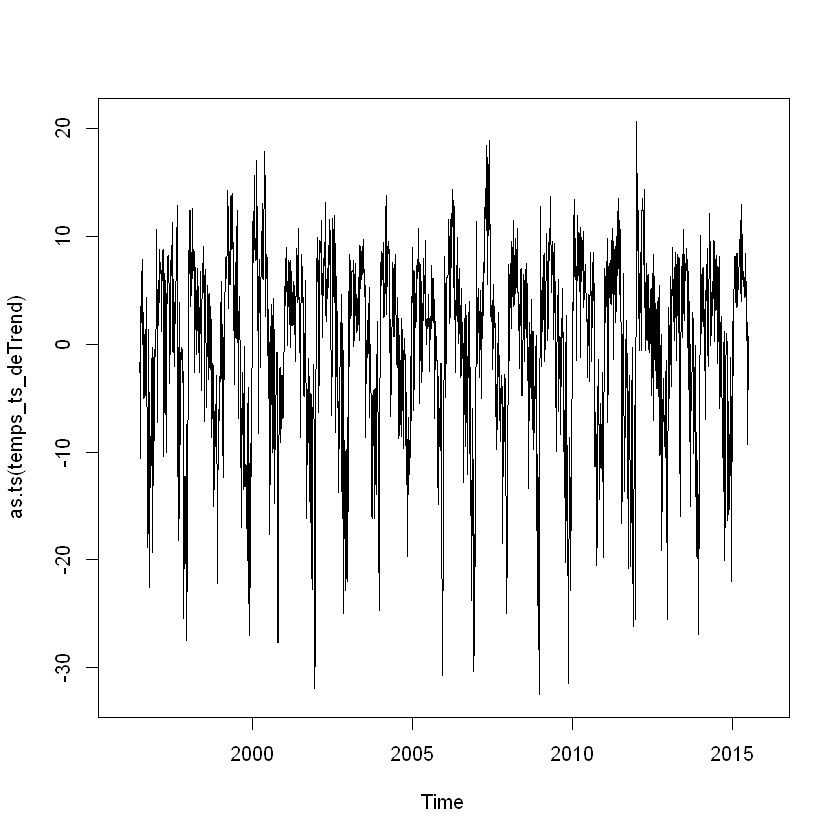

```r
# De-trending our time series
temps_ts_deTrend <- temps_ts - myts_decomposed$trend
plot(as.ts(temps_ts_deTrend))
```

It looks like de-trending our original time series didnt help us see the seasonality of our data.

### Build a HoltWinters model

We will use the original time series to build our exponential smoothing model.

- We will inspect single, double and triple exponential smoothing

```r
# single exp smoothing using Holt-Winters filtering
single_hw_fit <- HoltWinters(temps_ts, beta=FALSE, gamma=FALSE)
single_hw_fit
```

```
Holt-Winters exponential smoothing without trend and without seasonal component.

Call:
HoltWinters(x = temps_ts, beta = FALSE, gamma = FALSE)

Smoothing parameters:
 alpha: 0.8388021
 beta : FALSE
 gamma: FALSE

Coefficients:
      [,1]
a 63.30952
```

The output of `HoltWinters()` are `alpha = 0.839` and `a = 63.3`. The `alpha` parameter is closer to 1 which implies that our series doesnt have much randomness. With less random fluctuations in our system, we can trust the current observation. This means that today's baseline is closer to the observed data. In our case, the baseline is `a = 63.3`

```r
# double exp smoothing using Holt-Winters filtering
double_hw_fit  <- HoltWinters(temps_ts,gamma=FALSE)
double_hw_fit
```

```
Holt-Winters exponential smoothing with trend and without seasonal component.

Call:
HoltWinters(x = temps_ts, gamma = FALSE)

Smoothing parameters:
 alpha: 0.8445729
 beta : 0.003720884
 gamma: FALSE

Coefficients:
        [,1]
a 63.2530022
b -0.0729933
```

both `bet`a and the trend estimate `b` are close to zero which indicates that no significant trend is observed - same as what we saw using single exponential smoothing

```r
# triple exp smoothing using Holt-Winters filtering
triple_hw_fit <- HoltWinters(x = temps_ts, seasonal = "multiplicative")
triple_hw_fit
```

```
Holt-Winters exponential smoothing with trend and multiplicative seasonal component.

Call:
HoltWinters(x = temps_ts, seasonal = "multiplicative")

Smoothing parameters:
 alpha: 0.615003
 beta : 0
 gamma: 0.5495256

Coefficients:
             [,1]
a    73.679517064
b    -0.004362918
s1    1.239022317
s2    1.234344062
s3    1.159509551
s4    1.175247483
s5    1.171344196
s6    1.151038408
s7    1.139383104
s8    1.130484528
s9    1.110487514
s10   1.076242879
s11   1.041044609
s12   1.058139281
s13   1.032496529
s14   1.036257448
s15   1.019348815
s16   1.026754142
s17   1.071170378
s18   1.054819556
s19   1.084397734
s20   1.064605879
s21   1.109827336
s22   1.112670130
s23   1.103970506
s24   1.102771209
s25   1.091264692
s26   1.084518342
```

[output cut: 82 more lines]

```
s109  0.830111282
s110  0.829086181
s111  0.818367239
s112  0.863958784
s113  0.912057203
s114  0.898308248
s115  0.878723779
s116  0.848971946
s117  0.813891909
s118  0.846821392
s119  0.819121827
s120  0.851036184
s121  0.820416491
s122  0.851581233
s123  0.874038407
```

Using the `HoltWinters()`, we get the most optimized values for the smoothing parameters:

| Smoothing parameters | Value |
| --- | --- |
| alpha | 0.615003 |
| beta | 0 |
| gamma | 0.5495256 |

`a` - current estimate of baseline `73.679517064`  
`b` - current estimate of the trend coeff `-0.004362918` Since the trend estimate coefficient is almost zero, we can conclude that there isn't a significant pattern seen in our data

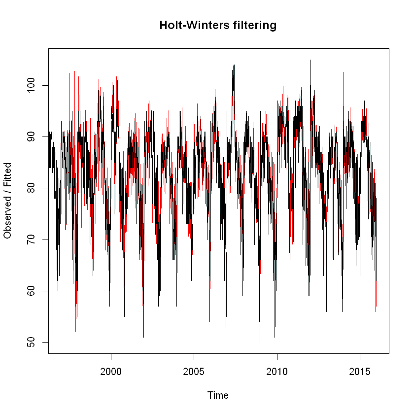

```r
plot(triple_hw_fit)
```

The forecasts estimates are in red, while the original data is in black. We can see here that the forecasts are not much smoother than the original data, which can be an indication that our data doesnt have any observed trends.

We can instect the filtered series by looking at the `$fitted` term

```r
head(triple_hw_fit$fitted,5)
tail(triple_hw_fit$fitted, 5)
```

| xhat | level | trend | season |
| --- | --- | --- | --- |
| 87.23653 | 82.87739 | -0.004362918 | 1.052653 |
| 90.42182 | 82.15059 | -0.004362918 | 1.100742 |
| 92.99734 | 81.91055 | -0.004362918 | 1.135413 |
| 90.94030 | 81.90763 | -0.004362918 | 1.110338 |
| 83.99917 | 81.93634 | -0.004362918 | 1.025231 |

|  | xhat | level | trend | season |
| --- | --- | --- | --- | --- |
| [2333,] | 69.70436 | 81.07435 | -0.004362918 | 0.8598048 |
| [2334,] | 57.02909 | 71.26750 | -0.004362918 | 0.8002607 |
| [2335,] | 72.14646 | 87.37935 | -0.004362918 | 0.8257107 |
| [2336,] | 73.89293 | 85.77627 | -0.004362918 | 0.8615051 |
| [2337,] | 75.83100 | 82.99285 | -0.004362918 | 0.9137532 |

We further see that the trend component is closer to zero, which means that our temperature data doesnt show any significant changes wether it's an increase or decrease in temperature over the 20 years time span. We can export the season column into .csv file and we can plot it to see if we can notice any seasonality

```r
mat <- matrix(triple_hw_fit$fitted[,4], nrow = 123)
head(mat, 3)
csv_export <- write.csv(mat, "data.csv")
```

| 1.052653 | 1.049468 | 1.120607 | 1.103336 | 1.118390 | 1.108172 | 1.140906 | 1.140574 | 1.125438 | 1.122063 | 1.161415 | 1.198102 | 1.198910 | 1.243012 | 1.243781 | 1.238435 | 1.300204 | 1.290647 | 1.254521 |
| --- | --- | --- | --- | --- | --- | --- | --- | --- | --- | --- | --- | --- | --- | --- | --- | --- | --- | --- |
| 1.100742 | 1.099653 | 1.108025 | 1.098323 | 1.110184 | 1.116213 | 1.126827 | 1.154074 | 1.142187 | 1.131889 | 1.144549 | 1.134661 | 1.153433 | 1.165431 | 1.172935 | 1.190735 | 1.191956 | 1.219190 | 1.228826 |
| 1.135413 | 1.135420 | 1.139096 | 1.142831 | 1.143201 | 1.138495 | 1.129678 | 1.156092 | 1.165657 | 1.147982 | 1.149459 | 1.135756 | 1.153310 | 1.155197 | 1.157286 | 1.169773 | 1.189915 | 1.172309 | 1.169045 |

The plot below represents the original temp data, the average temperature over the 20 years.

we can see that there is a slight change in temperature around end of August, but the most considerable change doesnt show until around mid September that's when we see a drop in temperature

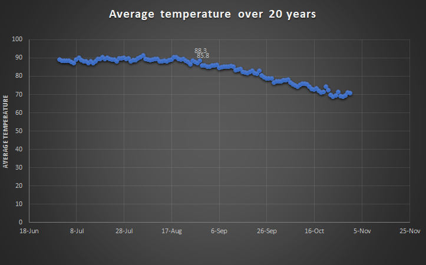

[figure not shown]

### Conclusion:

Using 3 different types of exponential smoothing to fit our temperature data and having an alpha closer to 1, and both beta and b almost equal to zero, we can conclude that Atlanta temperatures from July to October over the period of 1996 and 2015 have no trend.